# The recipe for happiness: a predictive linear regression analysis

Marco D’Ercole - Statistical Methods in Data Science Final Project

2023-09-07

## 1. Introduction

### 1.1 The question: What makes the human being happy?

The covid-19 pandemic has increased the desire in society for the pursuit of well-being, happiness, personal and spiritual fulfillment much more than was felt in the past. The desire to live happily is high, and there are many questions in society about what it is that actually makes one happy. Up to the present day in society, GDP has gradually become synonymous with the level of well-being of a state’s population. But more and more scholars believe there are many other indicators to be taken into account in order to be able to define whether a population is on average happy or not ([GeoPop: scientific journal](https://www.geopop.it/cose-il-pil-e-come-si-misura-il-benessere-di-uno-stato/#:~:text=Dalla%20fine%20della%20Seconda%20Guerra,della%20popolazione%20di%20uno%20Stato.)). The purpose of my study is just that. To understand what is the recipe for happiness. what are the factors that determine greater or lesser well-being in the populations of our planet.

### 1.2 The data

To address my study, I used a [kaggle dataset](https://www.kaggle.com/datasets/sougatapramanick/happiness-index-2018-2019?select=2019.csv) from 2019 containing **156 nations of the world** (rows) and 7 variables (columns):

- **Score**: This variable defines the average happiness score of the population in each state. The score ranges from 1 to 10 and was obtained by asking a sample population how happy they felt.

The other 6 variables available will be the subject of our study because through them we will try to understand whether or not they influence a nation’s happiness. There are:

- **GDP per capita**: which represents the economic well-being of a country’s residents.
- **freedom to make life choices**: represents the level of autonomy and control individuals have over their lives.
- **health life expectancy**: indicates the length of time individuals can expect to live in good health.
- **perception of corruption**: reflects the extent to which corruption is perceived to be prevalent in a society.
- **social support**: measures the extent to which individuals have access to support from family, friends, and other social networks.
- **Generosity**: How much people help each other.

**GOAL**: To make a predictive linear regression analysis of the score of happiness given the indices available. Is happiness correlated to GDP, freedom, health, perception of corruption, social support and generosity? how much and how do they affect?

## 2 Happiness around the world - a comprenshion of the data

One cannot begin to study what influences happiness without first having a global view of the happiness score in the various nations of the world.

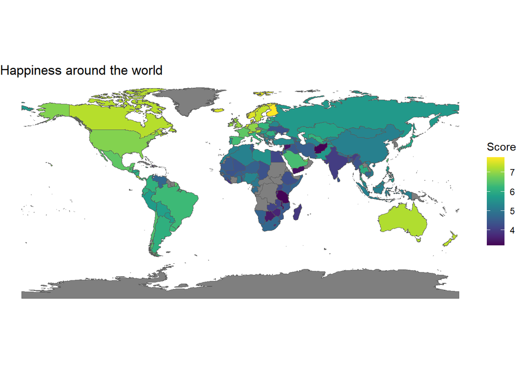

The map shows very clearly the **first position of Finland**, which leads the ranking with its bright yellow. It is then followed mostly by nations from Europe, Oceania and North America, which together are the happinest continents. Back them there are Asia and Africa. This figure is made clearer by the following barplot showing the average happiness scores of nations by continent.

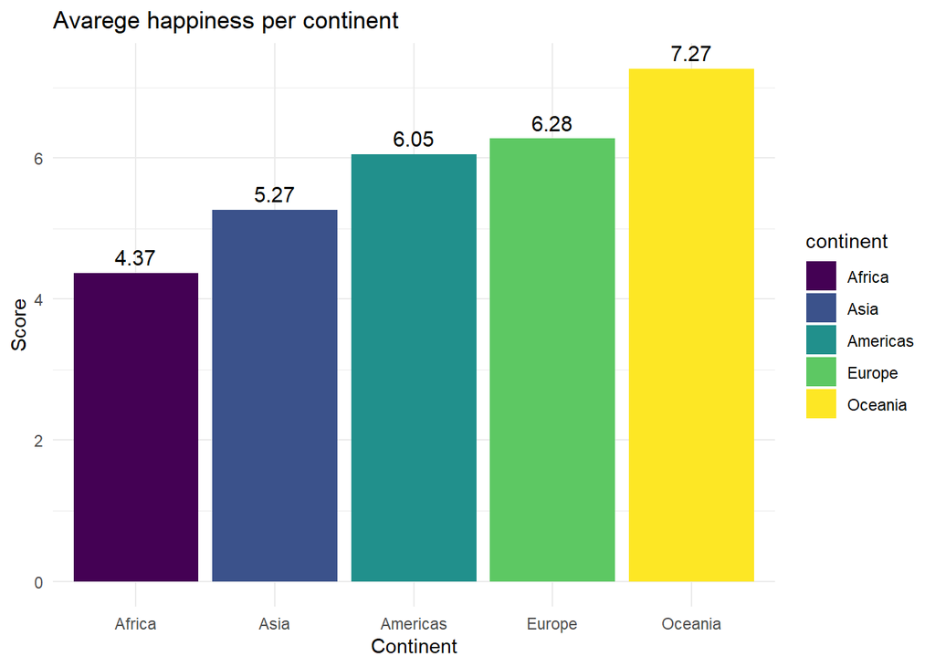

Instead, the next chart shows in more detail which are the 20 happiest nations on the planet. It will be sad to find out that unfortunately **Italy** is not present being in **36th position**. Finland, Denmark and Norway are on the podium instead. **All European nations continue to lead the ranking** with the exception of New Zealand (8), Canada (9), Australia (11), Costa Rica (12), Israel (13), United States (19).

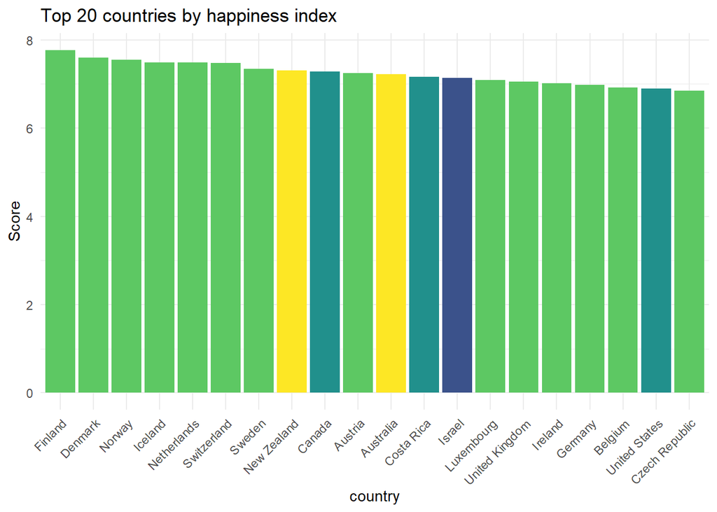

To conclude let’s plot the distribution of the happiness score.

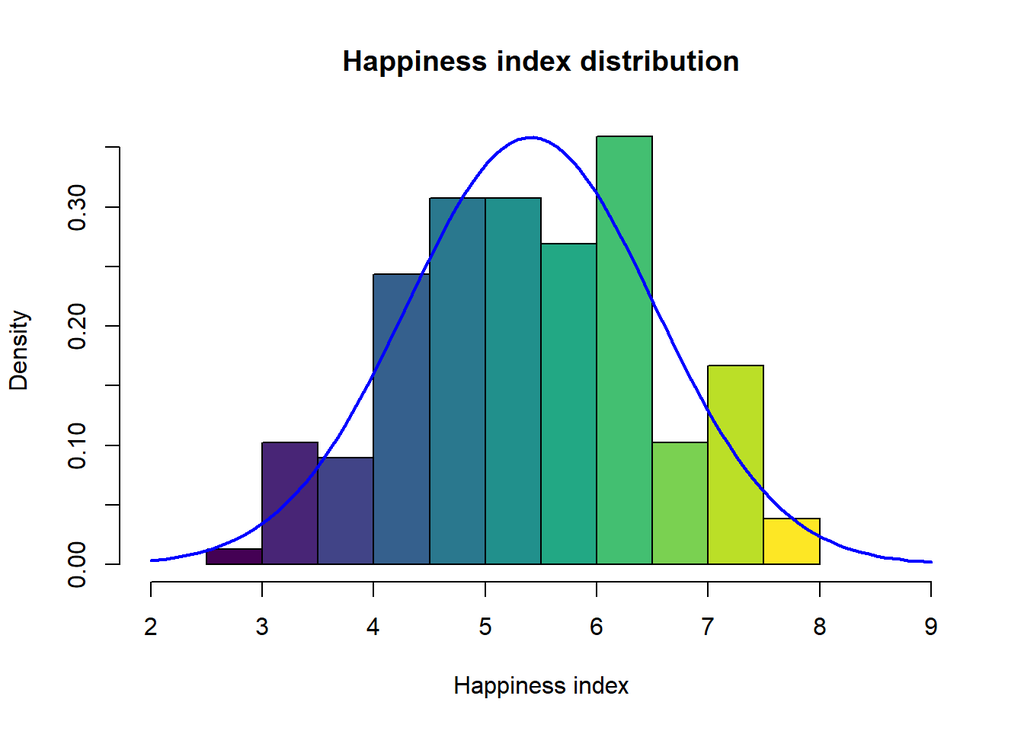

Now the trend it’s more visible. It seems that it has a normal distribution. Let’s test it with a **Shapiro test**!

```
##
##  Shapiro-Wilk normality test
##
## data:  X2019$score
## W = 0.9872, p-value = 0.1633
```

In the shapiro test **the null hypotesis is that the population is normally distributed**. The p-value obtained is 0.1633, while it is bigger than the significative level (0.05) there are **no sufficient evidence to reject the null hypotesis** that the happiness score follows a normal distribution.

## 3 Descriptive Analysis

### 3.1 Discovering the variables

The first intuition and curiosity that i had was if the countries that have high score in the different variables are still in high positions in the happiness score. To discover more about this idea let’s display a table that shows **which nations lead the ranking for each index** and see their position in the ranking for all the other indices.

| index | country | happiness | GDPpc | Socialsupport | Life | Freedom | Generosity | Corruptionperception |
| --- | --- | --- | --- | --- | --- | --- | --- | --- |
| score | Finland | 1 | 23 | 2 | 28 | 5 | 92 | 4 |
| GDPpc | Qatar | 29 | 1 | 70 | 45 | 21 | 53 | 26 |
| socialsupport | Iceland | 4 | 15 | 1 | 15 | 7 | 8 | 49 |
| life | Singapore | 34 | 3 | 36 | 1 | 20 | 22 | 1 |
| freedom | Uzbekistan | 41 | 106 | 11 | 87 | 1 | 13 | 18 |
| generosity | Myanmar | 131 | 108 | 97 | 115 | 30 | 1 | 25 |
| corruptionperception | Singapore | 34 | 3 | 36 | 1 | 20 | 22 | 1 |

Qatar is the country with the highest GDP per capita and is placed 29th in the happiness ranking, Iceland is first in social support and in the happiness index it is fourth, Singapore is first in life expectancy and in the happiness index happiness is 34th. What is most surprising is **Myanmar, which is first for generosity and 131st for happiness**. It therefore seems that generosity does not have much to do with happiness, however further investigation is needed also because the **positions in the ranking are very variable** and there do not appear to be distinct blocks.

But first, a curiosity: Italy (36th for happiness) has these positions in the ranking. Ranking very high for life expectancy (9th position) but very low for perceptions of corruption and freedom to make life choices (135 and 133)

| country | rank | GDPpc_rank | socialsupport_rank | life_rank | freedom_rank | generosity_rank | corruptionperception_rank |
| --- | --- | --- | --- | --- | --- | --- | --- |
| Italy | 36 | 30 | 23 | 9 | 133 | 89 | 135 |

To continue our research and understand whether the variables at our disposal influence the happiness index or not let’s study the distributions.

### 3.2 Study of the distributions

Let’s explore the **idea that there are two distinct blocks of nations**: that is, the nations that have high scores in the indices available are also those that have high levels of happiness and viceversa.

In the following histograms i tried to study the different distributions of happiness but considering different situations. **for every variable** i used once the **top half (TH) of the distribution**, later i used the **second half (SH)** and i tried to compare this two. In the figure is possible to see in the first row all the distributions of happiness score only considering the top half countries by every variables and in the second row there is the same work using the second half.

Variables: GDP per capita, social support, life expectancy

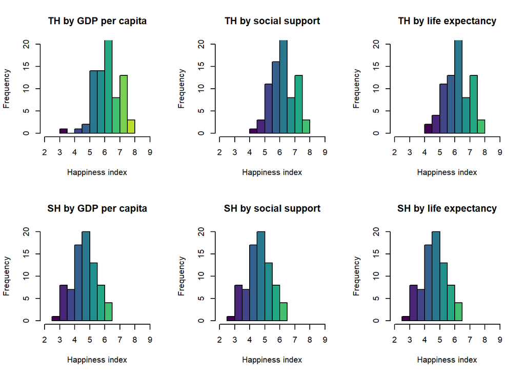

Variables: freedom, corruption perception, generosity

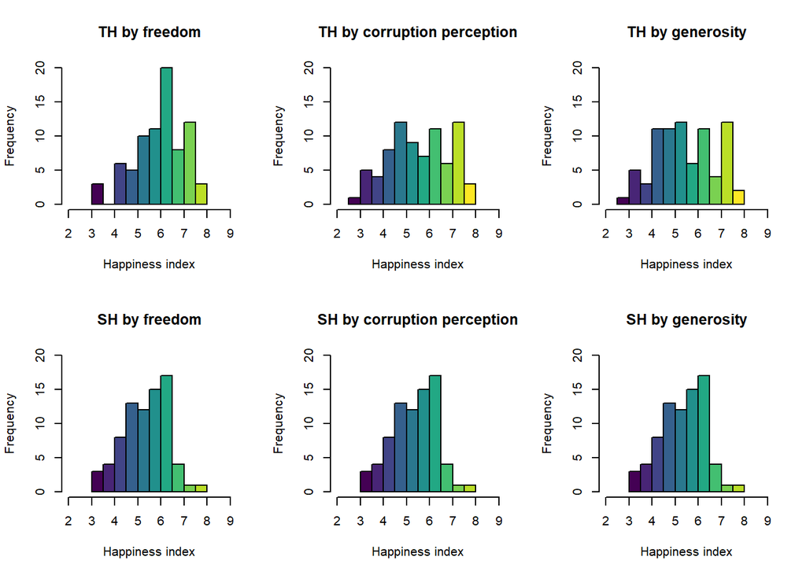

This just give a first idea that the countries that are in the top half of GDP per capita, social support, life expectancy, freedom as visible are the ones that have an happinest score higher than the countries that are in the second half. For the variables corruption perception and generosity this is less visible.

we delve deeper into these observations by viewing the data in **boxplots** rather than looking at the distribution in histograms. Let’s plot the Top Half (TH) and Bottom Half (BH).

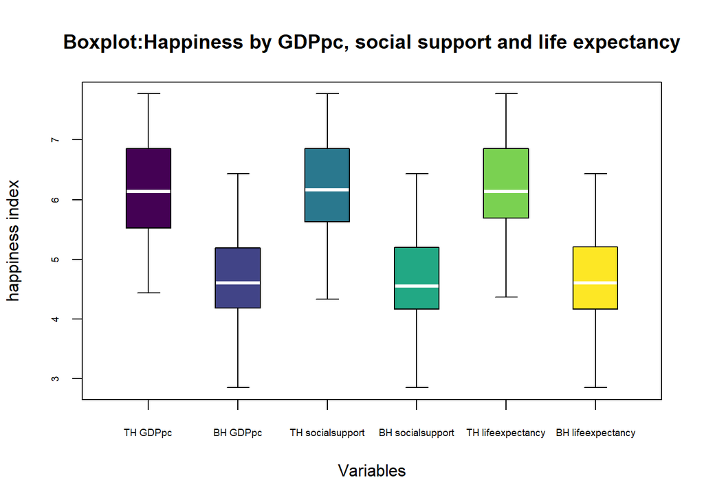

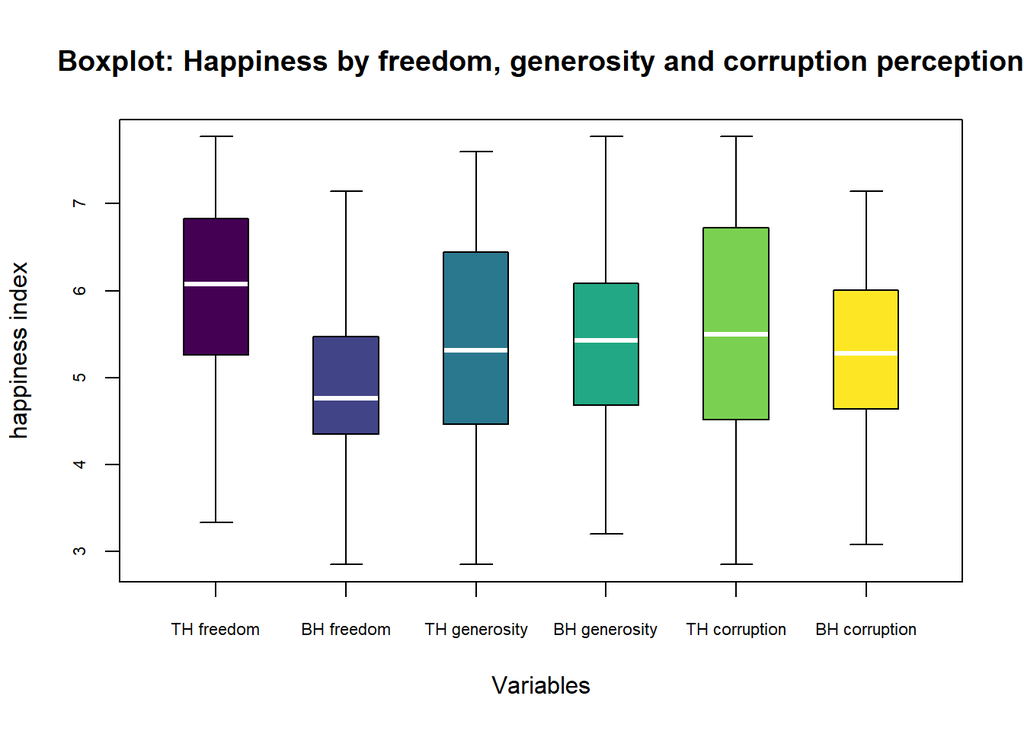

The Boxplot confirmed that the variables **GDP per capita, social support, life expectancy and freedom seems to be linked to happiness**, while for generosity and corruption perception if they have high values of score, this doesn’t mean they will have high happiness score too.

### 3.3 The correlations between variables

To have the confirm of this idea we need to study the correlation between the variables.

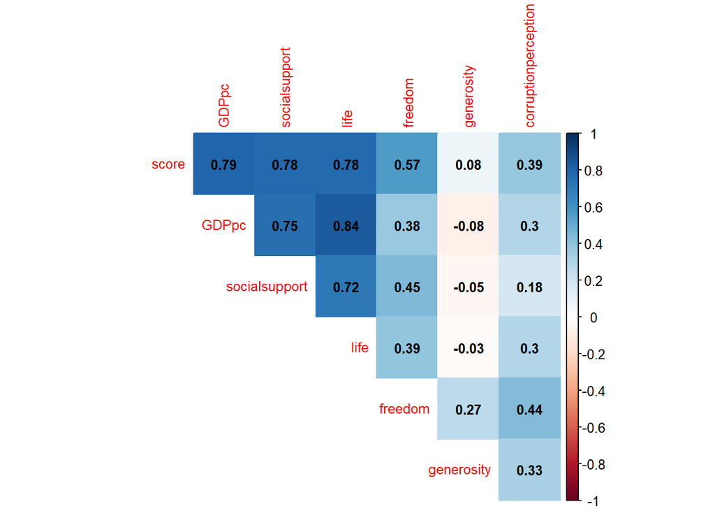

The impact of the variables in influencing happiness score is more undenstandable from these **scatterplots**.

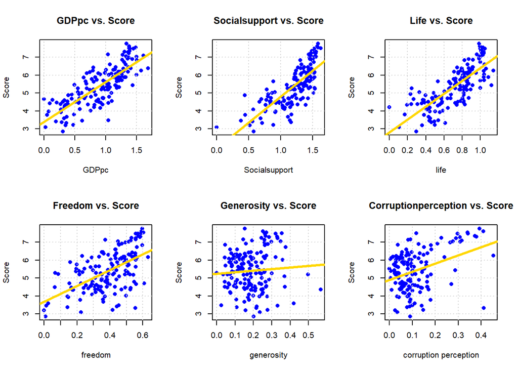

The variables GDPpc, Social support, Life and Freedom have a linear trend with the happiness score while generosity and corruption perception not a lot but this was already intuitable since the 2 variables were hardly correlated with happiness at all.

Let’s go to analyse with a frequentist and bayesian approach if the models whether the linearity intuition is confirmed in the model to predict the happiness score or not.

## 4 The frequentist approach

### 4.1 The linear model

Now that we know our data it’s time to build some models and try to understand which fit better in our data. All the analysis seen so far converge in one direction: linearity! So creating our first model the most obvious choice seems the linear model!

Before creating a Bayesian style linear model let’s try with the frequentist model, the simplest one.

How does it work?

**The assumption is that happiness (the response variable y) is the linear combination of a set of predictor variables $X$ and weights $\beta$, net of a random error component $\epsilon \sim N(0,\sigma^2)$:**

$$y = X\beta + \epsilon$$
How to choose the weights $\beta$? Have to be taken the weights that minimizes the Residual Sum of Squares (RSS), that is the difference between the true y-values and the predicted y-hat values.

**The idea behind this method is that everything is contained within the data**, and therefore the result obtained is a **single point estimate of the parameters**, based on our training data.

Let’s build the model first including all the variables!

```r
modello = lm(score ~ GDPpc + socialsupport + life + freedom + generosity + corruptionperception, X2019)
summary(modello)
```

```
##
## Call:
## lm(formula = score ~ GDPpc + socialsupport + life + freedom +
##     generosity + corruptionperception, data = X2019)
##
## Residuals:
##      Min       1Q   Median       3Q      Max
## -1.75304 -0.35306  0.05703  0.36695  1.19059
##
## Coefficients:
##                      Estimate Std. Error t value Pr(>|t|)
## (Intercept)            1.7952     0.2111   8.505 1.77e-14 ***
## GDPpc                  0.7754     0.2182   3.553 0.000510 ***
## socialsupport          1.1242     0.2369   4.745 4.83e-06 ***
## life                   1.0781     0.3345   3.223 0.001560 **
## freedom                1.4548     0.3753   3.876 0.000159 ***
## generosity             0.4898     0.4977   0.984 0.326709
## corruptionperception   0.9723     0.5424   1.793 0.075053 .
## ---
## Signif. codes:  0 '***' 0.001 '**' 0.01 '*' 0.05 '.' 0.1 ' ' 1
##
## Residual standard error: 0.5335 on 149 degrees of freedom
## Multiple R-squared:  0.7792, Adjusted R-squared:  0.7703
## F-statistic: 87.62 on 6 and 149 DF,  p-value: < 2.2e-16
```

Each **estimated regression coefficient** provides informations about the relationship between an independent variable and the happiness score, taking into account the other variables in the model. For example, the coefficient for GDPpc is approximately 0.7754. This means that, holding other variables fixed, a one unit increase in gross domestic product per capita is associated with an increase of approximately 0.7754 units in the happiness score. **Some coefficients are significant with an high degree of confidence** (such as GDPpc, socialsupport, life, and freedom), **while others** (such as generosity and corruptionperception) **appear not to be statistically significant**.

The overall model has an **R-squared (R^2)** of approximately **0.7792**, meaning that approximately 77.92% of the variability in the happiness score can be explained by the independent variables included in the model. This indicates that the model has a good ability to explain variations in the data.

The p-value associated with the F-statistic is very small (very close to zero), which suggests that at least one of the independent variables in the model is significantly associated with the happiness score. This indicates that the model as a whole is statistically significant.

```r
modello = lm(score ~ GDPpc + socialsupport + life + freedom, X2019)
summary(modello)
```

```
##
## Call:
## lm(formula = score ~ GDPpc + socialsupport + life + freedom,
##     data = X2019)
##
## Residuals:
##      Min       1Q   Median       3Q      Max
## -1.86584 -0.34594  0.03403  0.43676  1.13076
##
## Coefficients:
##               Estimate Std. Error t value Pr(>|t|)
## (Intercept)     1.8921     0.1994   9.491  < 2e-16 ***
## GDPpc           0.8105     0.2165   3.745 0.000256 ***
## socialsupport   1.0166     0.2347   4.331 2.70e-05 ***
## life            1.1414     0.3373   3.384 0.000910 ***
## freedom         1.8458     0.3404   5.423 2.28e-07 ***
## ---
## Signif. codes:  0 '***' 0.001 '**' 0.01 '*' 0.05 '.' 0.1 ' ' 1
##
## Residual standard error: 0.5398 on 151 degrees of freedom
## Multiple R-squared:  0.7709, Adjusted R-squared:  0.7649
## F-statistic:   127 on 4 and 151 DF,  p-value: < 2.2e-16
```

Even though i removed two variables, **77% of the variance remained explained** and therefore the contribution that those variables gave is practically zero and it is preferable to have a simpler model with fewer variables between the two models this last one seems better.

### 4.2 The predictive model

Let’s divide now the data into a **train set and a test set** to see the predictive capability of this model. I will consider 75% of data for the train set and 25% for the test set.

```r
# Step 0: set seed for reproducibility
set.seed(1234)

# Let's consider 75% of data for the train set

# Step 1: train-test split
ind <- sample(1:nrow(X2019), size = 117, replace = F)
train <- X2019[ind, ]
test <-  X2019[-ind, ]

# Step 2: fit the model
model_pred = lm(score ~ GDPpc + socialsupport + life + freedom, train)

# Step 3: predict
test$y_hat <- predict(model_pred, newdata = test)

# Step 4: compute the mean of the residuals
test$residuals <- test$score - test$y_hat

# Calculate the mean of the residuals
mean_residual <- mean(test$residuals)
print(mean_residual)
```

```
## [1] 0.1394668
```

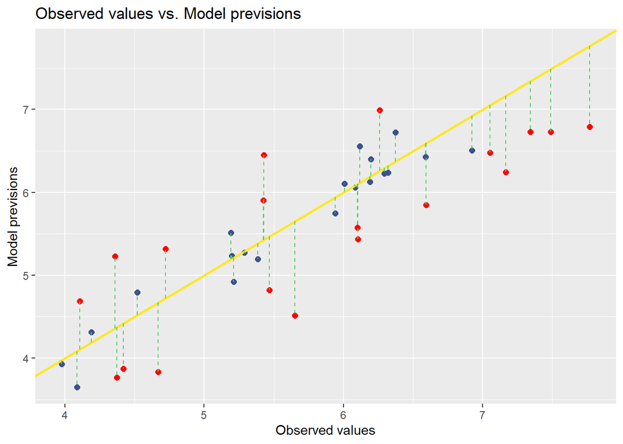

The **mean of the residual** is close to zero (**0.139**) this means that the model predict quite well our data. In the graph is visible in the x-axis the observed values and in the y-axis the model previsions values. The points are draw in two different colors. The blue points are the ones with the distance between the points and the line less than the mean of th residual. Instead the red points are the ones that are distant more than the average.

## 5 The Bayesian approach

Why to use a **bayesian model** if the frequentist is simpler?

A bayesian model can include **information sources in addition** to the data: Background information, expert opinion, common knowledge.

If in the frequentist approach the main idea was that the dataset contains enough information to accurately estimate the $\beta$ coefficients. Now in the Bayesian approach this foundational assumption is missing.

In this new approach the **information** is given not only from the data but **it is added from a prior probability** distribution on the parameters to be estimated too. So we will no longer have a single point estimate of the parameters, but that uncertainty in the form of a probability distribution is also incorporated into this new model.

The linear combination between predictors and weights is retaind, but this time $y$ is seen as:

$$y \sim N(\beta^T X,\sigma^2I)$$

The **goal** of this new approach is thus to **identify the posterior distribution** for these weights from a prior distribution assigned to them.

**How to decide the prior distribution?**

Actually there are two possibilities:

1. to use specific priors on the parameters, perhaps exploiting prior knowledge from the literature or from some specialized papers about the topic being discussed.
2. to use generic prior distributions (non-informative priors) as discussed by [Andrew Gelman](https://github.com/stan-dev/stan/wiki/Prior-Choice-Recommendations).

While there is not literature about this topic we are going to use a non-informative prior. In particular a **weakly informative prior**. By a “weakly informative” prior, we mean that, if there is a reasonably large amount of data, probability will dominate and the prior will not be important. However, if the data are sparse, this “weakly informative prior” will strongly influence the posterior inference. The term “weakly informative” is implicitly compared to a default flat prior. If there is no prior information directly on the scale of the parameters, it is common to have some information on the order of magnitude scale of the results, which can be used to create weakly informative priors.

why weakly informative rather than fully informative? the idea is that the loss of precision due to a prior that is a little too weak (relative to the true population distribution of the parameters or the current state of expert knowledge) is less severe than the gain in robustness due to the inclusion of parts of the parameter space that might be relevant.

The weakly informative priors is distributed according to an **N(0,10)**. In Jags it is used the precision that is 1/variance so we are going to use dnorm(0,0.1)

So let us try to create the bayesian model using the R2jags package.

```r
set.seed(1234)

jags_data <- list(
  N = nrow(X2019),
  score = X2019$score,                  # Y
  GDPpc = X2019$GDPpc,                  # X1
  socialsupport = X2019$socialsupport,  # X2
  life = X2019$life,                    # X3
  freedom = X2019$freedom,              # X4
  generosity = X2019$generosity,        # X5
  corruptionperception = X2019$corruptionperception   #X6
)

jags_code <- "
model {
  # Priors
  beta0 ~ dnorm(0, 0.1)
  beta_GDPpc ~ dnorm(0, 0.1)
  beta_socialsupport ~ dnorm(0, 0.1)
  beta_life ~ dnorm(0, 0.1)
  beta_freedom ~ dnorm(0, 0.1)
  beta_generosity ~ dnorm(0, 0.1)
  beta_corruptionperception ~ dnorm(0, 0.1)
  tau ~ dgamma(0.1, 0.1)


  # --> Normal Linear Model <---
  for (i in 1:N) {
    mu[i] <- beta0 +beta_GDPpc * GDPpc[i] + beta_socialsupport * socialsupport[i] +
             beta_life * life[i] + beta_freedom * freedom[i] +
             beta_generosity * generosity[i] + beta_corruptionperception * corruptionperception[i]


    score[i] ~ dnorm(mu[i], tau)
  }
}
"

jags_model <- jags(data = jags_data, inits = NULL,
                   parameters.to.save = c("beta0", "beta_GDPpc", "beta_socialsupport",
                                          "beta_life", "beta_freedom",
                                          'beta_generosity', 'beta_corruptionperception', "tau"),
                   model.file = textConnection(jags_code),
                   n.chains = 3, n.iter = 2000, n.burnin = 500, n.thin = 1)
jags_model
```

```
## Inference for Bugs model at "4", fit using jags,
##  3 chains, each with 2000 iterations (first 500 discarded)
##  n.sims = 4500 iterations saved
##                           mu.vect sd.vect    2.5%     25%     50%     75%
## beta0                       1.791   0.209   1.380   1.650   1.788   1.930
## beta_GDPpc                  0.777   0.218   0.347   0.633   0.776   0.917
## beta_corruptionperception   0.958   0.535  -0.078   0.603   0.954   1.322
## beta_freedom                1.447   0.373   0.703   1.198   1.453   1.691
## beta_generosity             0.500   0.496  -0.449   0.158   0.481   0.846
## beta_life                   1.073   0.335   0.402   0.857   1.075   1.298
## beta_socialsupport          1.131   0.236   0.677   0.971   1.128   1.292
## tau                         3.501   0.414   2.736   3.218   3.485   3.774
## deviance                  247.750   4.140 241.784 244.732 247.074 250.030
##                             97.5%  Rhat n.eff
## beta0                       2.202 1.001  2900
## beta_GDPpc                  1.213 1.001  4500
## beta_corruptionperception   2.008 1.001  4500
## beta_freedom                2.172 1.001  2800
## beta_generosity             1.482 1.001  4500
## beta_life                   1.718 1.001  4500
## beta_socialsupport          1.594 1.001  4500
## tau                         4.354 1.003  1100
## deviance                  257.693 1.001  4500
##
## For each parameter, n.eff is a crude measure of effective sample size,
## and Rhat is the potential scale reduction factor (at convergence, Rhat=1).
##
## DIC info (using the rule, pD = var(deviance)/2)
## pD = 8.6 and DIC = 256.3
## DIC is an estimate of expected predictive error (lower deviance is better).
```

Considering this **let’s remove corruption perception and generosity** that have 0 inside the interval distribution.

```r
set.seed(1234)

jags_data2 <- list(
  N = nrow(X2019),
  score = X2019$score,                  # Y
  GDPpc = X2019$GDPpc,                  # X1
  socialsupport = X2019$socialsupport,  # X2
  life = X2019$life,                    # X3
  freedom = X2019$freedom              # X4
)

jags_code2 <- "
model {
  # Priors
  beta0 ~ dnorm(0, 0.1)
  beta_GDPpc ~ dnorm(0, 0.1)
  beta_socialsupport ~ dnorm(0, 0.1)
  beta_life ~ dnorm(0, 0.1)
  beta_freedom ~ dnorm(0, 0.1)
  tau ~ dgamma(0.1, 0.1)


  # --> Normal Linear Model <---
  for (i in 1:N) {
    mu[i] <- beta0 +beta_GDPpc * GDPpc[i] + beta_socialsupport * socialsupport[i] +
             beta_life * life[i] + beta_freedom * freedom[i]


    score[i] ~ dnorm(mu[i], tau)
  }
}
"

jags_model2 <- jags(data = jags_data2, inits = NULL,
                   parameters.to.save =c("beta0","beta_GDPpc","beta_socialsupport",
                                          "beta_life", "beta_freedom",
                                          "tau"),
                   model.file = textConnection(jags_code2),
                   n.chains = 3, n.iter = 2000, n.burnin = 500, n.thin = 1)
jags_model2
```

```
## Inference for Bugs model at "5", fit using jags,
##  3 chains, each with 2000 iterations (first 500 discarded)
##  n.sims = 4500 iterations saved
##                    mu.vect sd.vect    2.5%     25%     50%     75%   97.5%
## beta0                1.889   0.201   1.492   1.752   1.894   2.024   2.278
## beta_GDPpc           0.803   0.220   0.372   0.657   0.798   0.952   1.249
## beta_freedom         1.829   0.346   1.157   1.597   1.825   2.062   2.501
## beta_life            1.144   0.342   0.478   0.914   1.145   1.380   1.804
## beta_socialsupport   1.029   0.236   0.565   0.872   1.030   1.184   1.497
## tau                  3.423   0.382   2.724   3.154   3.408   3.670   4.228
## deviance           251.369   3.442 246.516 248.822 250.763 253.292 259.417
##                     Rhat n.eff
## beta0              1.001  4500
## beta_GDPpc         1.001  4500
## beta_freedom       1.001  3700
## beta_life          1.001  4500
## beta_socialsupport 1.001  4500
## tau                1.001  4500
## deviance           1.001  2900
##
## For each parameter, n.eff is a crude measure of effective sample size,
## and Rhat is the potential scale reduction factor (at convergence, Rhat=1).
##
## DIC info (using the rule, pD = var(deviance)/2)
## pD = 5.9 and DIC = 257.3
## DIC is an estimate of expected predictive error (lower deviance is better).
```

**How to understand what is the best model?**

**THE DIC!**

The DIC (Deviance Information Criterion) is a measure used in Bayesian modeling to assess the goodness of fit of a model to data. It is **based on the model’s deviance**, which represents a measure of how much the model deviates from the observed data. In general, a model with a lower deviance fits the data better. However, the DIC also takes into account the complexity of the model, aiming to strike a **balance between data fit and model parsimony**.

The DIC is calculated as follows:

**DIC = mean sample deviance + effective sample deviance**

Where:

Mean sample deviance is a measure of the discrepancy between the observed data and the model’s average predictions. A lower value indicates a better fit of the model to the data.

Effective sample deviance is a measure of the variation in deviance across samples sampled from the posterior distribution of the model. This term accounts for model complexity.

In general, the model with the **lowest DIC** value is considered the **best among candidate models** because it provides a good fit to the data without excessive complexity.

Analyzing the two different models the first one has a DIC equal to 256.3, the second one 257.3. Since DIC increases very little and since removing the two variables makes our model simpler and with the interval estimates of all parameters containing no zeros, we choose this second model as the best.

## 6 Diagnostics of the model

Model diagnostics help us to understand **how much we can trust the estimates** obtained from our model. This is important because we want to ensure that our estimates are accurate and reliable.

In essence, we are looking for signs that tell us whether our MCMC algorithm is reaching a stable and consistent result. If we notice convergence issues, we should take steps to improve the algorithm or our data; otherwise, our estimates may be unreliable.

Let’s check the diagnostic for our second bayesian model.

### 6.1 The R-Hat

A first simple tool is the R-hat (potential scale reduction factor) diagnostic. Typically, parameters are considered to have **adequate convergence when R-hat is less than 1.1**. In this case the R-hat for all parameters is close to 1, which suggests good convergence of the model. This is a good sign because it indicates that Markov Chain Monte Carlo (MCMC) have reached convergence.

Anyway the R-hat is not enough to make sure that the MCMC algorithm has reached the stationary distribution. Let’s discover other diagnostics!

### 6.2 N.eff

n.eff (the effective sample size) is a measure used in Bayesian statistics to assess the quality and efficiency of samples generated by Markov Chain Monte Carlo (MCMC) algorithms.

The effective sample size tells **how many of the MCMC samples are effectively independent** and representative of the target posterior distribution. High correlation infact may require a very large number of samples to provide the same information contained in a few Monte Carlo samples and this bring in a loss of efficiency. It’s better so to have indipendent Monte Carlo samples.

As effective sample size increase, autocorrelation decrease, if the ESS of all parameters coincides with the number of MCMC samples generated by the algorithm, it indicate the almost complete absence of any form of autocorrelation.

An **high n.eff is desirable** because it indicates greater precision in parameter estimates. An high n.eff indicates that the MCMC sample is rich in useful information for estimating model parameters, while a low n.eff suggests that the sample may not be informative enough.

In our model the number of simulation is 4500 and almost all the parameters have n.eff 4500 (just freedom has 3700). this is very good.

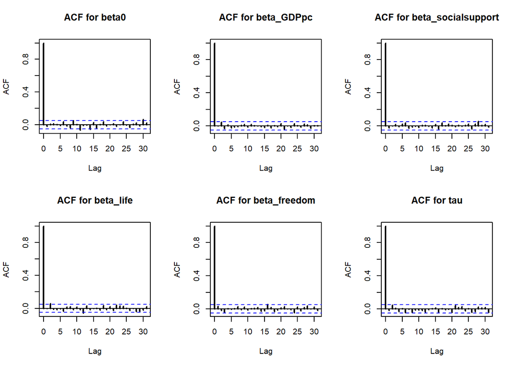

### 6.3 Trace Plot

A traceplot is a type of graph used in Markov Chain Monte Carlo (MCMC) analysis **to visualize the behavior of chains** when sampling statistical parameters. Specifically, it is used to examine the evolution of chains over time (or iterations) and to identify any convergence issues.

The traceplot essentially shows a path or “trace” of sampled values for a parameter over the course of iterations. A well-behaved traceplot should look like “white noise” or a random stochastic process, with no obvious trends.

Ideally we want the **chains in each trace plot to be stable** (centered around one value) **and well-mixed** (all chains are overlapping around the same value).

If the traceplot shows a chain getting “stuck” in a particular region or exhibits cyclic patterns may indicate convergence issues or unwanted autocorrelation.

In summary, what does the trace plot allow us to visualise?

**Comparison between the beginning and end of the chain**: By examining the results of the MCMC chain, we can ask whether the values obtained at the beginning of the chain and those obtained at the end are similar or different. If they are very different, it could be a sign that the chain has not “converged,” meaning it is not reaching a stable value. This could lead to imprecise estimates.

**Comparison between chains started from different points**: When we start multiple MCMC chains from different initial points, we expect them to eventually converge to the same result. If this does not happen, and the chains diverge significantly, it could be a sign of convergence problems in the MCMC algorithm. In this case, we should be cautious about relying on the estimates from our model.

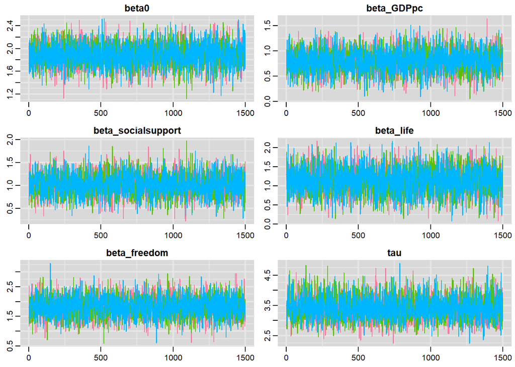

On the x-axis, we have iterations or time, which represents the number of samples taken by the MCMC chain.

On the y-axis, we have the sampled values for the specific parameter we are monitoring.

### 6.4 Density Plot

the density plot is used **to display the marginal distribution of model parameter estimates obtained by sampling from Markov Monte Carlo chains**. This results in the following steps:

1. MCMC sampling: In a Bayesian model, parameter estimates are not obtained through a single analytical solution but through MCMC sampling.
2. Parameter estimates: For each model parameter (such as averages, standard deviations, quantiles, etc.), a set of samples will be generated. These samples represent the parameter estimates.
3. Density Plot creation: To visualise the distribution of parameter estimates, a density plot can be created for each parameter. In a Bayesian density plot, the **x-axis** represents the **possible values of the parameter**, while the **y-axis** represents the estimated probability **density** of finding the parameter at that particular value. the peak of the density plot could represent the most probable estimate of the parameter, while the width of the peak indicates its uncertainty.

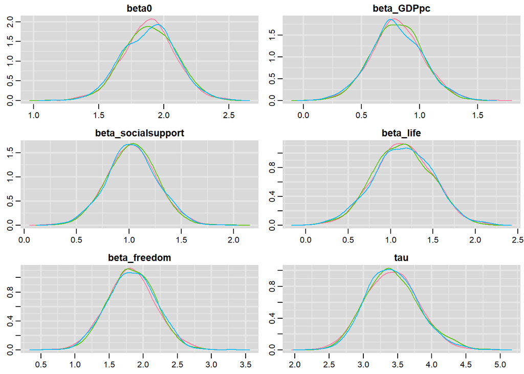

## 7 Conclusions

To conclude it is possible to say that the index GDPpc, social support, life and freedom are linked to happiness and the bayesian model is a good predictive model for calculating the happiness score of a population from these variables.